# Risk Factor Analysis

## Outcome Variable

**Outcome Variable:** pers_wast

## Predictor Variables

**Intervention Variable:** birthlen

**Adjustment Set:**

unadjusted

## Stratifying Variables

The analysis was stratified on these variable(s):

- agecat
- studyid
- country

## Data Summary

| agecat | studyid | country | birthlen | pers_wast | n_cell | n |
| --- | --- | --- | --- | --- | --- | --- |
| 0-24 months | ki0047075b-MAL-ED | BANGLADESH | >=50 cm | 0 | 26 | 241 |
| 0-24 months | ki0047075b-MAL-ED | BANGLADESH | >=50 cm | 1 | 3 | 241 |
| 0-24 months | ki0047075b-MAL-ED | BANGLADESH | <48 cm | 0 | 120 | 241 |
| 0-24 months | ki0047075b-MAL-ED | BANGLADESH | <48 cm | 1 | 8 | 241 |
| 0-24 months | ki0047075b-MAL-ED | BANGLADESH | [48-50) cm | 0 | 83 | 241 |
| 0-24 months | ki0047075b-MAL-ED | BANGLADESH | [48-50) cm | 1 | 1 | 241 |
| 0-24 months | ki0047075b-MAL-ED | BRAZIL | >=50 cm | 0 | 33 | 180 |
| 0-24 months | ki0047075b-MAL-ED | BRAZIL | >=50 cm | 1 | 0 | 180 |
| 0-24 months | ki0047075b-MAL-ED | BRAZIL | <48 cm | 0 | 72 | 180 |
| 0-24 months | ki0047075b-MAL-ED | BRAZIL | <48 cm | 1 | 1 | 180 |
| 0-24 months | ki0047075b-MAL-ED | BRAZIL | [48-50) cm | 0 | 74 | 180 |
| 0-24 months | ki0047075b-MAL-ED | BRAZIL | [48-50) cm | 1 | 0 | 180 |
| 0-24 months | ki0047075b-MAL-ED | INDIA | >=50 cm | 0 | 23 | 197 |
| 0-24 months | ki0047075b-MAL-ED | INDIA | >=50 cm | 1 | 1 | 197 |
| 0-24 months | ki0047075b-MAL-ED | INDIA | <48 cm | 0 | 97 | 197 |
| 0-24 months | ki0047075b-MAL-ED | INDIA | <48 cm | 1 | 7 | 197 |
| 0-24 months | ki0047075b-MAL-ED | INDIA | [48-50) cm | 0 | 61 | 197 |
| 0-24 months | ki0047075b-MAL-ED | INDIA | [48-50) cm | 1 | 8 | 197 |
| 0-24 months | ki0047075b-MAL-ED | NEPAL | >=50 cm | 0 | 37 | 172 |
| 0-24 months | ki0047075b-MAL-ED | NEPAL | >=50 cm | 1 | 1 | 172 |
| 0-24 months | ki0047075b-MAL-ED | NEPAL | <48 cm | 0 | 68 | 172 |
| 0-24 months | ki0047075b-MAL-ED | NEPAL | <48 cm | 1 | 0 | 172 |
| 0-24 months | ki0047075b-MAL-ED | NEPAL | [48-50) cm | 0 | 66 | 172 |
| 0-24 months | ki0047075b-MAL-ED | NEPAL | [48-50) cm | 1 | 0 | 172 |
| 0-24 months | ki0047075b-MAL-ED | PERU | >=50 cm | 0 | 32 | 271 |
| 0-24 months | ki0047075b-MAL-ED | PERU | >=50 cm | 1 | 0 | 271 |
| 0-24 months | ki0047075b-MAL-ED | PERU | <48 cm | 0 | 135 | 271 |
| 0-24 months | ki0047075b-MAL-ED | PERU | <48 cm | 1 | 1 | 271 |
| 0-24 months | ki0047075b-MAL-ED | PERU | [48-50) cm | 0 | 103 | 271 |
| 0-24 months | ki0047075b-MAL-ED | PERU | [48-50) cm | 1 | 0 | 271 |

[output cut: 444 more lines]

The following strata were considered:

- agecat: 0-24 months, studyid: ki0047075b-MAL-ED, country: BANGLADESH
- agecat: 0-24 months, studyid: ki0047075b-MAL-ED, country: BRAZIL
- agecat: 0-24 months, studyid: ki0047075b-MAL-ED, country: INDIA
- agecat: 0-24 months, studyid: ki0047075b-MAL-ED, country: NEPAL
- agecat: 0-24 months, studyid: ki0047075b-MAL-ED, country: PERU
- agecat: 0-24 months, studyid: ki0047075b-MAL-ED, country: SOUTH AFRICA
- agecat: 0-24 months, studyid: ki0047075b-MAL-ED, country: TANZANIA, UNITED REPUBLIC OF
- agecat: 0-24 months, studyid: ki1000108-CMC-V-BCS-2002, country: INDIA
- agecat: 0-24 months, studyid: ki1000108-IRC, country: INDIA
- agecat: 0-24 months, studyid: ki1000109-EE, country: PAKISTAN
- agecat: 0-24 months, studyid: ki1000109-ResPak, country: PAKISTAN
- agecat: 0-24 months, studyid: ki1000304b-SAS-CompFeed, country: INDIA
- agecat: 0-24 months, studyid: ki1017093-NIH-Birth, country: BANGLADESH
- agecat: 0-24 months, studyid: ki1017093b-PROVIDE, country: BANGLADESH
- agecat: 0-24 months, studyid: ki1017093c-NIH-Crypto, country: BANGLADESH
- agecat: 0-24 months, studyid: ki1101329-Keneba, country: GAMBIA
- agecat: 0-24 months, studyid: ki1114097-CMIN, country: BANGLADESH
- agecat: 0-24 months, studyid: ki1114097-CMIN, country: BRAZIL
- agecat: 0-24 months, studyid: ki1114097-CMIN, country: GUINEA-BISSAU
- agecat: 0-24 months, studyid: ki1114097-CMIN, country: PERU
- agecat: 0-24 months, studyid: ki1114097-CONTENT, country: PERU
- agecat: 0-24 months, studyid: ki1119695-PROBIT, country: BELARUS
- agecat: 0-24 months, studyid: ki1126311-ZVITAMBO, country: ZIMBABWE
- agecat: 0-24 months, studyid: ki1135781-COHORTS, country: GUATEMALA
- agecat: 0-24 months, studyid: ki1135781-COHORTS, country: INDIA
- agecat: 0-24 months, studyid: ki1135781-COHORTS, country: PHILIPPINES
- agecat: 0-24 months, studyid: kiGH5241-JiVitA-3, country: BANGLADESH
- agecat: 0-24 months, studyid: kiGH5241-JiVitA-4, country: BANGLADESH
- agecat: 0-6 months, studyid: ki0047075b-MAL-ED, country: BANGLADESH
- agecat: 0-6 months, studyid: ki0047075b-MAL-ED, country: BRAZIL
- agecat: 0-6 months, studyid: ki0047075b-MAL-ED, country: INDIA
- agecat: 0-6 months, studyid: ki0047075b-MAL-ED, country: NEPAL
- agecat: 0-6 months, studyid: ki0047075b-MAL-ED, country: PERU
- agecat: 0-6 months, studyid: ki0047075b-MAL-ED, country: SOUTH AFRICA
- agecat: 0-6 months, studyid: ki0047075b-MAL-ED, country: TANZANIA, UNITED REPUBLIC OF
- agecat: 0-6 months, studyid: ki1000108-CMC-V-BCS-2002, country: INDIA
- agecat: 0-6 months, studyid: ki1000108-IRC, country: INDIA
- agecat: 0-6 months, studyid: ki1000109-EE, country: PAKISTAN
- agecat: 0-6 months, studyid: ki1000109-ResPak, country: PAKISTAN
- agecat: 0-6 months, studyid: ki1017093-NIH-Birth, country: BANGLADESH
- agecat: 0-6 months, studyid: ki1017093b-PROVIDE, country: BANGLADESH
- agecat: 0-6 months, studyid: ki1017093c-NIH-Crypto, country: BANGLADESH
- agecat: 0-6 months, studyid: ki1101329-Keneba, country: GAMBIA
- agecat: 0-6 months, studyid: ki1114097-CMIN, country: BANGLADESH
- agecat: 0-6 months, studyid: ki1114097-CMIN, country: GUINEA-BISSAU
- agecat: 0-6 months, studyid: ki1114097-CMIN, country: PERU
- agecat: 0-6 months, studyid: ki1114097-CONTENT, country: PERU
- agecat: 0-6 months, studyid: ki1119695-PROBIT, country: BELARUS
- agecat: 0-6 months, studyid: ki1126311-ZVITAMBO, country: ZIMBABWE
- agecat: 0-6 months, studyid: ki1135781-COHORTS, country: PHILIPPINES
- agecat: 0-6 months, studyid: kiGH5241-JiVitA-3, country: BANGLADESH
- agecat: 6-24 months, studyid: ki0047075b-MAL-ED, country: BANGLADESH
- agecat: 6-24 months, studyid: ki0047075b-MAL-ED, country: BRAZIL
- agecat: 6-24 months, studyid: ki0047075b-MAL-ED, country: INDIA
- agecat: 6-24 months, studyid: ki0047075b-MAL-ED, country: NEPAL
- agecat: 6-24 months, studyid: ki0047075b-MAL-ED, country: PERU
- agecat: 6-24 months, studyid: ki0047075b-MAL-ED, country: SOUTH AFRICA
- agecat: 6-24 months, studyid: ki0047075b-MAL-ED, country: TANZANIA, UNITED REPUBLIC OF
- agecat: 6-24 months, studyid: ki1000108-CMC-V-BCS-2002, country: INDIA
- agecat: 6-24 months, studyid: ki1000108-IRC, country: INDIA
- agecat: 6-24 months, studyid: ki1000109-EE, country: PAKISTAN
- agecat: 6-24 months, studyid: ki1000109-ResPak, country: PAKISTAN
- agecat: 6-24 months, studyid: ki1000304b-SAS-CompFeed, country: INDIA
- agecat: 6-24 months, studyid: ki1017093-NIH-Birth, country: BANGLADESH
- agecat: 6-24 months, studyid: ki1017093b-PROVIDE, country: BANGLADESH
- agecat: 6-24 months, studyid: ki1017093c-NIH-Crypto, country: BANGLADESH
- agecat: 6-24 months, studyid: ki1101329-Keneba, country: GAMBIA
- agecat: 6-24 months, studyid: ki1114097-CMIN, country: BANGLADESH
- agecat: 6-24 months, studyid: ki1114097-CMIN, country: BRAZIL
- agecat: 6-24 months, studyid: ki1114097-CMIN, country: GUINEA-BISSAU
- agecat: 6-24 months, studyid: ki1114097-CMIN, country: PERU
- agecat: 6-24 months, studyid: ki1114097-CONTENT, country: PERU
- agecat: 6-24 months, studyid: ki1119695-PROBIT, country: BELARUS
- agecat: 6-24 months, studyid: ki1126311-ZVITAMBO, country: ZIMBABWE
- agecat: 6-24 months, studyid: ki1135781-COHORTS, country: GUATEMALA
- agecat: 6-24 months, studyid: ki1135781-COHORTS, country: INDIA
- agecat: 6-24 months, studyid: ki1135781-COHORTS, country: PHILIPPINES
- agecat: 6-24 months, studyid: kiGH5241-JiVitA-3, country: BANGLADESH
- agecat: 6-24 months, studyid: kiGH5241-JiVitA-4, country: BANGLADESH

### Dropped Strata

Some strata were dropped due to rare outcomes:

- agecat: 0-24 months, studyid: ki0047075b-MAL-ED, country: BANGLADESH
- agecat: 0-24 months, studyid: ki0047075b-MAL-ED, country: BRAZIL
- agecat: 0-24 months, studyid: ki0047075b-MAL-ED, country: INDIA
- agecat: 0-24 months, studyid: ki0047075b-MAL-ED, country: NEPAL
- agecat: 0-24 months, studyid: ki0047075b-MAL-ED, country: PERU
- agecat: 0-24 months, studyid: ki0047075b-MAL-ED, country: SOUTH AFRICA
- agecat: 0-24 months, studyid: ki0047075b-MAL-ED, country: TANZANIA, UNITED REPUBLIC OF
- agecat: 0-24 months, studyid: ki1000108-CMC-V-BCS-2002, country: INDIA
- agecat: 0-24 months, studyid: ki1000109-EE, country: PAKISTAN
- agecat: 0-24 months, studyid: ki1000109-ResPak, country: PAKISTAN
- agecat: 0-24 months, studyid: ki1000304b-SAS-CompFeed, country: INDIA
- agecat: 0-24 months, studyid: ki1017093-NIH-Birth, country: BANGLADESH
- agecat: 0-24 months, studyid: ki1017093b-PROVIDE, country: BANGLADESH
- agecat: 0-24 months, studyid: ki1017093c-NIH-Crypto, country: BANGLADESH
- agecat: 0-24 months, studyid: ki1114097-CMIN, country: BANGLADESH
- agecat: 0-24 months, studyid: ki1114097-CMIN, country: BRAZIL
- agecat: 0-24 months, studyid: ki1114097-CMIN, country: GUINEA-BISSAU
- agecat: 0-24 months, studyid: ki1114097-CMIN, country: PERU
- agecat: 0-24 months, studyid: ki1114097-CONTENT, country: PERU
- agecat: 0-24 months, studyid: ki1119695-PROBIT, country: BELARUS
- agecat: 0-24 months, studyid: ki1135781-COHORTS, country: GUATEMALA
- agecat: 0-6 months, studyid: ki0047075b-MAL-ED, country: BANGLADESH
- agecat: 0-6 months, studyid: ki0047075b-MAL-ED, country: BRAZIL
- agecat: 0-6 months, studyid: ki0047075b-MAL-ED, country: INDIA
- agecat: 0-6 months, studyid: ki0047075b-MAL-ED, country: NEPAL
- agecat: 0-6 months, studyid: ki0047075b-MAL-ED, country: PERU
- agecat: 0-6 months, studyid: ki0047075b-MAL-ED, country: SOUTH AFRICA
- agecat: 0-6 months, studyid: ki0047075b-MAL-ED, country: TANZANIA, UNITED REPUBLIC OF
- agecat: 0-6 months, studyid: ki1000108-CMC-V-BCS-2002, country: INDIA
- agecat: 0-6 months, studyid: ki1000109-EE, country: PAKISTAN
- agecat: 0-6 months, studyid: ki1000109-ResPak, country: PAKISTAN
- agecat: 0-6 months, studyid: ki1017093-NIH-Birth, country: BANGLADESH
- agecat: 0-6 months, studyid: ki1017093b-PROVIDE, country: BANGLADESH
- agecat: 0-6 months, studyid: ki1017093c-NIH-Crypto, country: BANGLADESH
- agecat: 0-6 months, studyid: ki1114097-CMIN, country: BANGLADESH
- agecat: 0-6 months, studyid: ki1114097-CMIN, country: GUINEA-BISSAU
- agecat: 0-6 months, studyid: ki1114097-CMIN, country: PERU
- agecat: 0-6 months, studyid: ki1114097-CONTENT, country: PERU
- agecat: 0-6 months, studyid: ki1119695-PROBIT, country: BELARUS
- agecat: 0-6 months, studyid: ki1126311-ZVITAMBO, country: ZIMBABWE
- agecat: 0-6 months, studyid: kiGH5241-JiVitA-3, country: BANGLADESH
- agecat: 6-24 months, studyid: ki0047075b-MAL-ED, country: BANGLADESH
- agecat: 6-24 months, studyid: ki0047075b-MAL-ED, country: BRAZIL
- agecat: 6-24 months, studyid: ki0047075b-MAL-ED, country: INDIA
- agecat: 6-24 months, studyid: ki0047075b-MAL-ED, country: NEPAL
- agecat: 6-24 months, studyid: ki0047075b-MAL-ED, country: PERU
- agecat: 6-24 months, studyid: ki0047075b-MAL-ED, country: SOUTH AFRICA
- agecat: 6-24 months, studyid: ki0047075b-MAL-ED, country: TANZANIA, UNITED REPUBLIC OF
- agecat: 6-24 months, studyid: ki1000108-CMC-V-BCS-2002, country: INDIA
- agecat: 6-24 months, studyid: ki1000109-EE, country: PAKISTAN
- agecat: 6-24 months, studyid: ki1000109-ResPak, country: PAKISTAN
- agecat: 6-24 months, studyid: ki1000304b-SAS-CompFeed, country: INDIA
- agecat: 6-24 months, studyid: ki1017093-NIH-Birth, country: BANGLADESH
- agecat: 6-24 months, studyid: ki1017093b-PROVIDE, country: BANGLADESH
- agecat: 6-24 months, studyid: ki1017093c-NIH-Crypto, country: BANGLADESH
- agecat: 6-24 months, studyid: ki1114097-CMIN, country: BANGLADESH
- agecat: 6-24 months, studyid: ki1114097-CMIN, country: BRAZIL
- agecat: 6-24 months, studyid: ki1114097-CMIN, country: GUINEA-BISSAU
- agecat: 6-24 months, studyid: ki1114097-CMIN, country: PERU
- agecat: 6-24 months, studyid: ki1114097-CONTENT, country: PERU
- agecat: 6-24 months, studyid: ki1119695-PROBIT, country: BELARUS
- agecat: 6-24 months, studyid: ki1135781-COHORTS, country: GUATEMALA

## Methods Detail

We’re interested in the causal parameters $E[Y_a]$ for all values of $a \in \mathcal{A}$. These parameters represent the mean outcome if, possibly contrary to fact, we intervened to set all units to have $A=a$. Under the randomization and positivity assumptions, these are identified by the statistical parameters $\psi_a=E_W[E_{Y|A,W}(Y|A=a,W)]$. In addition, we’re interested in the mean of $Y$, $E[Y]$ under no intervention (the observed mean). We will estimate these parameters by using SuperLearner to fit the relevant likelihood factors – $E_{Y|A,W}(Y|A=a,W)$ and $p(A=a|W)$, and then updating our likelihood fit using a joint TMLE.

For unadjusted analyses ($W=\{\}$), initial likelihoods were estimated using Lrnr_glm to estimate the simple $E(Y|A)$ and Lrnr_mean to estimate $p(A)$. For adjusted analyses, a small library containing Lrnr_glmnet, Lrnr_xgboost, and Lrnr_mean was used.

Having estimated these parameters, we will then use the delta method to estimate relative risks and attributable risks relative to a prespecified baseline level of $A$.

# Results Detail

## Results Plots

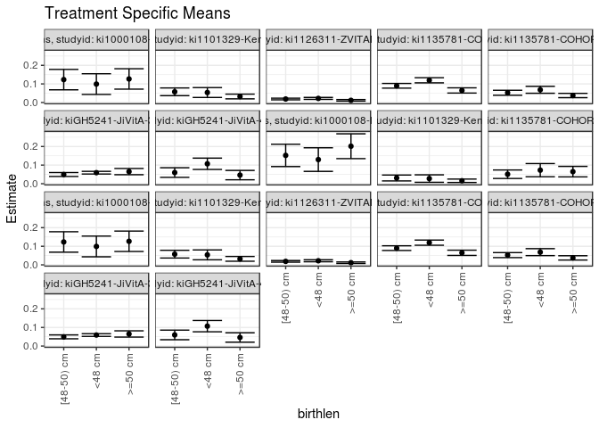

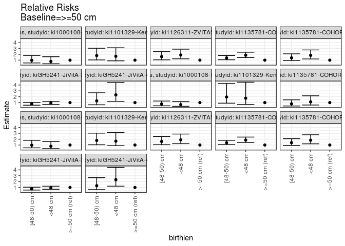

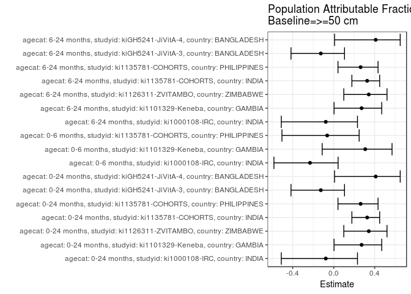

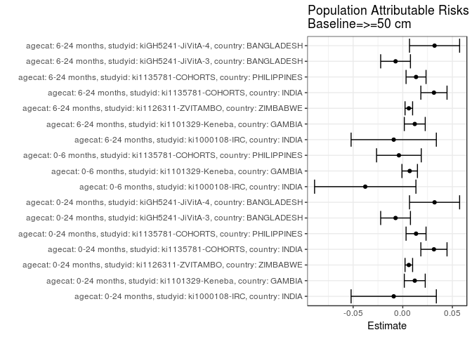

## Results Table

### Parameter: TSM

| agecat | studyid | country | intervention_level | baseline_level | estimate | ci_lower | ci_upper |
| --- | --- | --- | --- | --- | --- | --- | --- |
| 0-24 months | ki1000108-IRC | INDIA | >=50 cm | NA | 0.1267606 | 0.0719684 | 0.1815528 |
| 0-24 months | ki1000108-IRC | INDIA | <48 cm | NA | 0.0990991 | 0.0434426 | 0.1547556 |
| 0-24 months | ki1000108-IRC | INDIA | [48-50) cm | NA | 0.1231884 | 0.0682846 | 0.1780922 |
| 0-24 months | ki1101329-Keneba | GAMBIA | >=50 cm | NA | 0.0323887 | 0.0196381 | 0.0451393 |
| 0-24 months | ki1101329-Keneba | GAMBIA | <48 cm | NA | 0.0537634 | 0.0272886 | 0.0802383 |
| 0-24 months | ki1101329-Keneba | GAMBIA | [48-50) cm | NA | 0.0576132 | 0.0368903 | 0.0783360 |
| 0-24 months | ki1126311-ZVITAMBO | ZIMBABWE | >=50 cm | NA | 0.0117424 | 0.0076330 | 0.0158519 |
| 0-24 months | ki1126311-ZVITAMBO | ZIMBABWE | <48 cm | NA | 0.0220638 | 0.0167592 | 0.0273684 |
| 0-24 months | ki1126311-ZVITAMBO | ZIMBABWE | [48-50) cm | NA | 0.0188576 | 0.0144500 | 0.0232652 |
| 0-24 months | ki1135781-COHORTS | INDIA | >=50 cm | NA | 0.0648464 | 0.0507467 | 0.0789461 |
| 0-24 months | ki1135781-COHORTS | INDIA | <48 cm | NA | 0.1194523 | 0.1056389 | 0.1332657 |
| 0-24 months | ki1135781-COHORTS | INDIA | [48-50) cm | NA | 0.0900354 | 0.0774170 | 0.1026538 |
| 0-24 months | ki1135781-COHORTS | PHILIPPINES | >=50 cm | NA | 0.0376085 | 0.0260272 | 0.0491897 |
| 0-24 months | ki1135781-COHORTS | PHILIPPINES | <48 cm | NA | 0.0684736 | 0.0497743 | 0.0871729 |
| 0-24 months | ki1135781-COHORTS | PHILIPPINES | [48-50) cm | NA | 0.0525328 | 0.0391378 | 0.0659279 |
| 0-24 months | kiGH5241-JiVitA-3 | BANGLADESH | >=50 cm | NA | 0.0649855 | 0.0482736 | 0.0816973 |
| 0-24 months | kiGH5241-JiVitA-3 | BANGLADESH | <48 cm | NA | 0.0591984 | 0.0519772 | 0.0664195 |
| 0-24 months | kiGH5241-JiVitA-3 | BANGLADESH | [48-50) cm | NA | 0.0494037 | 0.0389011 | 0.0599064 |
| 0-24 months | kiGH5241-JiVitA-4 | BANGLADESH | >=50 cm | NA | 0.0461538 | 0.0209322 | 0.0713755 |
| 0-24 months | kiGH5241-JiVitA-4 | BANGLADESH | <48 cm | NA | 0.1070111 | 0.0765640 | 0.1374581 |
| 0-24 months | kiGH5241-JiVitA-4 | BANGLADESH | [48-50) cm | NA | 0.0598592 | 0.0340232 | 0.0856951 |
| 0-6 months | ki1000108-IRC | INDIA | >=50 cm | NA | 0.2014388 | 0.1346766 | 0.2682011 |
| 0-6 months | ki1000108-IRC | INDIA | <48 cm | NA | 0.1296296 | 0.0661981 | 0.1930612 |
| 0-6 months | ki1000108-IRC | INDIA | [48-50) cm | NA | 0.1521739 | 0.0921676 | 0.2121802 |
| 0-6 months | ki1101329-Keneba | GAMBIA | >=50 cm | NA | 0.0157143 | 0.0064979 | 0.0249307 |
| 0-6 months | ki1101329-Keneba | GAMBIA | <48 cm | NA | 0.0275591 | 0.0074195 | 0.0476986 |
| 0-6 months | ki1101329-Keneba | GAMBIA | [48-50) cm | NA | 0.0307018 | 0.0148627 | 0.0465408 |
| 0-6 months | ki1135781-COHORTS | PHILIPPINES | >=50 cm | NA | 0.0648464 | 0.0366331 | 0.0930597 |
| 0-6 months | ki1135781-COHORTS | PHILIPPINES | <48 cm | NA | 0.0728155 | 0.0373126 | 0.1083185 |
| 0-6 months | ki1135781-COHORTS | PHILIPPINES | [48-50) cm | NA | 0.0508475 | 0.0279491 | 0.0737458 |
| 6-24 months | ki1000108-IRC | INDIA | >=50 cm | NA | 0.1267606 | 0.0719684 | 0.1815528 |
| 6-24 months | ki1000108-IRC | INDIA | <48 cm | NA | 0.0990991 | 0.0434426 | 0.1547556 |
| 6-24 months | ki1000108-IRC | INDIA | [48-50) cm | NA | 0.1231884 | 0.0682846 | 0.1780922 |
| 6-24 months | ki1101329-Keneba | GAMBIA | >=50 cm | NA | 0.0323887 | 0.0196381 | 0.0451393 |
| 6-24 months | ki1101329-Keneba | GAMBIA | <48 cm | NA | 0.0537634 | 0.0272886 | 0.0802383 |
| 6-24 months | ki1101329-Keneba | GAMBIA | [48-50) cm | NA | 0.0576132 | 0.0368903 | 0.0783360 |
| 6-24 months | ki1126311-ZVITAMBO | ZIMBABWE | >=50 cm | NA | 0.0117424 | 0.0076330 | 0.0158519 |
| 6-24 months | ki1126311-ZVITAMBO | ZIMBABWE | <48 cm | NA | 0.0220638 | 0.0167592 | 0.0273684 |
| 6-24 months | ki1126311-ZVITAMBO | ZIMBABWE | [48-50) cm | NA | 0.0188576 | 0.0144500 | 0.0232652 |
| 6-24 months | ki1135781-COHORTS | INDIA | >=50 cm | NA | 0.0648464 | 0.0507467 | 0.0789461 |
| 6-24 months | ki1135781-COHORTS | INDIA | <48 cm | NA | 0.1194523 | 0.1056389 | 0.1332657 |
| 6-24 months | ki1135781-COHORTS | INDIA | [48-50) cm | NA | 0.0900354 | 0.0774170 | 0.1026538 |
| 6-24 months | ki1135781-COHORTS | PHILIPPINES | >=50 cm | NA | 0.0376085 | 0.0260272 | 0.0491897 |
| 6-24 months | ki1135781-COHORTS | PHILIPPINES | <48 cm | NA | 0.0684736 | 0.0497743 | 0.0871729 |
| 6-24 months | ki1135781-COHORTS | PHILIPPINES | [48-50) cm | NA | 0.0525328 | 0.0391378 | 0.0659279 |
| 6-24 months | kiGH5241-JiVitA-3 | BANGLADESH | >=50 cm | NA | 0.0649855 | 0.0482736 | 0.0816973 |
| 6-24 months | kiGH5241-JiVitA-3 | BANGLADESH | <48 cm | NA | 0.0591984 | 0.0519772 | 0.0664195 |
| 6-24 months | kiGH5241-JiVitA-3 | BANGLADESH | [48-50) cm | NA | 0.0494037 | 0.0389011 | 0.0599064 |
| 6-24 months | kiGH5241-JiVitA-4 | BANGLADESH | >=50 cm | NA | 0.0461538 | 0.0209322 | 0.0713755 |
| 6-24 months | kiGH5241-JiVitA-4 | BANGLADESH | <48 cm | NA | 0.1070111 | 0.0765640 | 0.1374581 |
| 6-24 months | kiGH5241-JiVitA-4 | BANGLADESH | [48-50) cm | NA | 0.0598592 | 0.0340232 | 0.0856951 |

### Parameter: E(Y)

| agecat | studyid | country | intervention_level | baseline_level | estimate | ci_lower | ci_upper |
| --- | --- | --- | --- | --- | --- | --- | --- |
| 0-24 months | ki1000108-IRC | INDIA | NA | NA | 0.1176471 | 0.0856708 | 0.1496233 |
| 0-24 months | ki1101329-Keneba | GAMBIA | NA | NA | 0.0444887 | 0.0340722 | 0.0549052 |
| 0-24 months | ki1126311-ZVITAMBO | ZIMBABWE | NA | NA | 0.0178475 | 0.0151485 | 0.0205464 |
| 0-24 months | ki1135781-COHORTS | INDIA | NA | NA | 0.0962597 | 0.0882935 | 0.1042259 |
| 0-24 months | ki1135781-COHORTS | PHILIPPINES | NA | NA | 0.0509986 | 0.0428544 | 0.0591428 |
| 0-24 months | kiGH5241-JiVitA-3 | BANGLADESH | NA | NA | 0.0577250 | 0.0519115 | 0.0635385 |
| 0-24 months | kiGH5241-JiVitA-4 | BANGLADESH | NA | NA | 0.0781929 | 0.0620891 | 0.0942966 |
| 0-6 months | ki1000108-IRC | INDIA | NA | NA | 0.1636364 | 0.1266348 | 0.2006379 |
| 0-6 months | ki1101329-Keneba | GAMBIA | NA | NA | 0.0226950 | 0.0149187 | 0.0304713 |
| 0-6 months | ki1135781-COHORTS | PHILIPPINES | NA | NA | 0.0609613 | 0.0448957 | 0.0770269 |
| 6-24 months | ki1000108-IRC | INDIA | NA | NA | 0.1176471 | 0.0856708 | 0.1496233 |
| 6-24 months | ki1101329-Keneba | GAMBIA | NA | NA | 0.0444887 | 0.0340722 | 0.0549052 |
| 6-24 months | ki1126311-ZVITAMBO | ZIMBABWE | NA | NA | 0.0178475 | 0.0151485 | 0.0205464 |
| 6-24 months | ki1135781-COHORTS | INDIA | NA | NA | 0.0962597 | 0.0882935 | 0.1042259 |
| 6-24 months | ki1135781-COHORTS | PHILIPPINES | NA | NA | 0.0509986 | 0.0428544 | 0.0591428 |
| 6-24 months | kiGH5241-JiVitA-3 | BANGLADESH | NA | NA | 0.0577250 | 0.0519115 | 0.0635385 |
| 6-24 months | kiGH5241-JiVitA-4 | BANGLADESH | NA | NA | 0.0781929 | 0.0620891 | 0.0942966 |

### Parameter: RR

| agecat | studyid | country | intervention_level | baseline_level | estimate | ci_lower | ci_upper |
| --- | --- | --- | --- | --- | --- | --- | --- |
| 0-24 months | ki1000108-IRC | INDIA | >=50 cm | >=50 cm | 1.0000000 | 1.0000000 | 1.000000 |
| 0-24 months | ki1000108-IRC | INDIA | <48 cm | >=50 cm | 0.7817818 | 0.3848567 | 1.588079 |
| 0-24 months | ki1000108-IRC | INDIA | [48-50) cm | >=50 cm | 0.9718196 | 0.5223305 | 1.808115 |
| 0-24 months | ki1101329-Keneba | GAMBIA | >=50 cm | >=50 cm | 1.0000000 | 1.0000000 | 1.000000 |
| 0-24 months | ki1101329-Keneba | GAMBIA | <48 cm | >=50 cm | 1.6599462 | 0.8836747 | 3.118140 |
| 0-24 months | ki1101329-Keneba | GAMBIA | [48-50) cm | >=50 cm | 1.7788066 | 1.0436165 | 3.031911 |
| 0-24 months | ki1126311-ZVITAMBO | ZIMBABWE | >=50 cm | >=50 cm | 1.0000000 | 1.0000000 | 1.000000 |
| 0-24 months | ki1126311-ZVITAMBO | ZIMBABWE | <48 cm | >=50 cm | 1.8789830 | 1.2289244 | 2.872900 |
| 0-24 months | ki1126311-ZVITAMBO | ZIMBABWE | [48-50) cm | >=50 cm | 1.6059385 | 1.0542918 | 2.446228 |
| 0-24 months | ki1135781-COHORTS | INDIA | >=50 cm | >=50 cm | 1.0000000 | 1.0000000 | 1.000000 |
| 0-24 months | ki1135781-COHORTS | INDIA | <48 cm | >=50 cm | 1.8420804 | 1.4399738 | 2.356474 |
| 0-24 months | ki1135781-COHORTS | INDIA | [48-50) cm | >=50 cm | 1.3884408 | 1.0719666 | 1.798347 |
| 0-24 months | ki1135781-COHORTS | PHILIPPINES | >=50 cm | >=50 cm | 1.0000000 | 1.0000000 | 1.000000 |
| 0-24 months | ki1135781-COHORTS | PHILIPPINES | <48 cm | >=50 cm | 1.8206957 | 1.2063869 | 2.747819 |
| 0-24 months | ki1135781-COHORTS | PHILIPPINES | [48-50) cm | >=50 cm | 1.3968346 | 0.9365072 | 2.083430 |
| 0-24 months | kiGH5241-JiVitA-3 | BANGLADESH | >=50 cm | >=50 cm | 1.0000000 | 1.0000000 | 1.000000 |
| 0-24 months | kiGH5241-JiVitA-3 | BANGLADESH | <48 cm | >=50 cm | 0.9109478 | 0.6873790 | 1.207232 |
| 0-24 months | kiGH5241-JiVitA-3 | BANGLADESH | [48-50) cm | >=50 cm | 0.7602278 | 0.5547660 | 1.041784 |
| 0-24 months | kiGH5241-JiVitA-4 | BANGLADESH | >=50 cm | >=50 cm | 1.0000000 | 1.0000000 | 1.000000 |
| 0-24 months | kiGH5241-JiVitA-4 | BANGLADESH | <48 cm | >=50 cm | 2.3185731 | 1.2162415 | 4.419995 |
| 0-24 months | kiGH5241-JiVitA-4 | BANGLADESH | [48-50) cm | >=50 cm | 1.2969483 | 0.6290489 | 2.673997 |
| 0-6 months | ki1000108-IRC | INDIA | >=50 cm | >=50 cm | 1.0000000 | 1.0000000 | 1.000000 |
| 0-6 months | ki1000108-IRC | INDIA | <48 cm | >=50 cm | 0.6435185 | 0.3563616 | 1.162067 |
| 0-6 months | ki1000108-IRC | INDIA | [48-50) cm | >=50 cm | 0.7554348 | 0.4513233 | 1.264463 |
| 0-6 months | ki1101329-Keneba | GAMBIA | >=50 cm | >=50 cm | 1.0000000 | 1.0000000 | 1.000000 |
| 0-6 months | ki1101329-Keneba | GAMBIA | <48 cm | >=50 cm | 1.7537581 | 0.6871083 | 4.476248 |
| 0-6 months | ki1101329-Keneba | GAMBIA | [48-50) cm | >=50 cm | 1.9537480 | 0.8946155 | 4.266784 |
| 0-6 months | ki1135781-COHORTS | PHILIPPINES | >=50 cm | >=50 cm | 1.0000000 | 1.0000000 | 1.000000 |
| 0-6 months | ki1135781-COHORTS | PHILIPPINES | <48 cm | >=50 cm | 1.1228922 | 0.5841713 | 2.158420 |
| 0-6 months | ki1135781-COHORTS | PHILIPPINES | [48-50) cm | >=50 cm | 0.7841213 | 0.4192175 | 1.466652 |
| 6-24 months | ki1000108-IRC | INDIA | >=50 cm | >=50 cm | 1.0000000 | 1.0000000 | 1.000000 |
| 6-24 months | ki1000108-IRC | INDIA | <48 cm | >=50 cm | 0.7817818 | 0.3848567 | 1.588079 |
| 6-24 months | ki1000108-IRC | INDIA | [48-50) cm | >=50 cm | 0.9718196 | 0.5223305 | 1.808115 |
| 6-24 months | ki1101329-Keneba | GAMBIA | >=50 cm | >=50 cm | 1.0000000 | 1.0000000 | 1.000000 |
| 6-24 months | ki1101329-Keneba | GAMBIA | <48 cm | >=50 cm | 1.6599462 | 0.8836747 | 3.118140 |
| 6-24 months | ki1101329-Keneba | GAMBIA | [48-50) cm | >=50 cm | 1.7788066 | 1.0436165 | 3.031911 |
| 6-24 months | ki1126311-ZVITAMBO | ZIMBABWE | >=50 cm | >=50 cm | 1.0000000 | 1.0000000 | 1.000000 |
| 6-24 months | ki1126311-ZVITAMBO | ZIMBABWE | <48 cm | >=50 cm | 1.8789830 | 1.2289244 | 2.872900 |
| 6-24 months | ki1126311-ZVITAMBO | ZIMBABWE | [48-50) cm | >=50 cm | 1.6059385 | 1.0542918 | 2.446228 |
| 6-24 months | ki1135781-COHORTS | INDIA | >=50 cm | >=50 cm | 1.0000000 | 1.0000000 | 1.000000 |
| 6-24 months | ki1135781-COHORTS | INDIA | <48 cm | >=50 cm | 1.8420804 | 1.4399738 | 2.356474 |
| 6-24 months | ki1135781-COHORTS | INDIA | [48-50) cm | >=50 cm | 1.3884408 | 1.0719666 | 1.798347 |
| 6-24 months | ki1135781-COHORTS | PHILIPPINES | >=50 cm | >=50 cm | 1.0000000 | 1.0000000 | 1.000000 |
| 6-24 months | ki1135781-COHORTS | PHILIPPINES | <48 cm | >=50 cm | 1.8206957 | 1.2063869 | 2.747819 |
| 6-24 months | ki1135781-COHORTS | PHILIPPINES | [48-50) cm | >=50 cm | 1.3968346 | 0.9365072 | 2.083430 |
| 6-24 months | kiGH5241-JiVitA-3 | BANGLADESH | >=50 cm | >=50 cm | 1.0000000 | 1.0000000 | 1.000000 |
| 6-24 months | kiGH5241-JiVitA-3 | BANGLADESH | <48 cm | >=50 cm | 0.9109478 | 0.6873790 | 1.207232 |
| 6-24 months | kiGH5241-JiVitA-3 | BANGLADESH | [48-50) cm | >=50 cm | 0.7602278 | 0.5547660 | 1.041784 |
| 6-24 months | kiGH5241-JiVitA-4 | BANGLADESH | >=50 cm | >=50 cm | 1.0000000 | 1.0000000 | 1.000000 |
| 6-24 months | kiGH5241-JiVitA-4 | BANGLADESH | <48 cm | >=50 cm | 2.3185731 | 1.2162415 | 4.419995 |
| 6-24 months | kiGH5241-JiVitA-4 | BANGLADESH | [48-50) cm | >=50 cm | 1.2969483 | 0.6290489 | 2.673997 |

### Parameter: PAR

| agecat | studyid | country | intervention_level | baseline_level | estimate | ci_lower | ci_upper |
| --- | --- | --- | --- | --- | --- | --- | --- |
| 0-24 months | ki1000108-IRC | INDIA | >=50 cm | NA | -0.0091135 | -0.0520559 | 0.0338289 |
| 0-24 months | ki1101329-Keneba | GAMBIA | >=50 cm | NA | 0.0121000 | 0.0015599 | 0.0226402 |
| 0-24 months | ki1126311-ZVITAMBO | ZIMBABWE | >=50 cm | NA | 0.0061051 | 0.0022936 | 0.0099165 |
| 0-24 months | ki1135781-COHORTS | INDIA | >=50 cm | NA | 0.0314133 | 0.0182304 | 0.0445962 |
| 0-24 months | ki1135781-COHORTS | PHILIPPINES | >=50 cm | NA | 0.0133901 | 0.0033280 | 0.0234522 |
| 0-24 months | kiGH5241-JiVitA-3 | BANGLADESH | >=50 cm | NA | -0.0072605 | -0.0222628 | 0.0077418 |
| 0-24 months | kiGH5241-JiVitA-4 | BANGLADESH | >=50 cm | NA | 0.0320390 | 0.0067946 | 0.0572835 |
| 0-6 months | ki1000108-IRC | INDIA | >=50 cm | NA | -0.0378025 | -0.0888698 | 0.0132648 |
| 0-6 months | ki1101329-Keneba | GAMBIA | >=50 cm | NA | 0.0069807 | -0.0008342 | 0.0147957 |
| 0-6 months | ki1135781-COHORTS | PHILIPPINES | >=50 cm | NA | -0.0038851 | -0.0264075 | 0.0186373 |
| 6-24 months | ki1000108-IRC | INDIA | >=50 cm | NA | -0.0091135 | -0.0520559 | 0.0338289 |
| 6-24 months | ki1101329-Keneba | GAMBIA | >=50 cm | NA | 0.0121000 | 0.0015599 | 0.0226402 |
| 6-24 months | ki1126311-ZVITAMBO | ZIMBABWE | >=50 cm | NA | 0.0061051 | 0.0022936 | 0.0099165 |
| 6-24 months | ki1135781-COHORTS | INDIA | >=50 cm | NA | 0.0314133 | 0.0182304 | 0.0445962 |
| 6-24 months | ki1135781-COHORTS | PHILIPPINES | >=50 cm | NA | 0.0133901 | 0.0033280 | 0.0234522 |
| 6-24 months | kiGH5241-JiVitA-3 | BANGLADESH | >=50 cm | NA | -0.0072605 | -0.0222628 | 0.0077418 |
| 6-24 months | kiGH5241-JiVitA-4 | BANGLADESH | >=50 cm | NA | 0.0320390 | 0.0067946 | 0.0572835 |

### Parameter: PAF

| agecat | studyid | country | intervention_level | baseline_level | estimate | ci_lower | ci_upper |
| --- | --- | --- | --- | --- | --- | --- | --- |
| 0-24 months | ki1000108-IRC | INDIA | >=50 cm | NA | -0.0774648 | -0.5113100 | 0.2318384 |
| 0-24 months | ki1101329-Keneba | GAMBIA | >=50 cm | NA | 0.2719802 | 0.0031447 | 0.4683152 |
| 0-24 months | ki1126311-ZVITAMBO | ZIMBABWE | >=50 cm | NA | 0.3420684 | 0.0983224 | 0.5199238 |
| 0-24 months | ki1135781-COHORTS | INDIA | >=50 cm | NA | 0.3263391 | 0.1772877 | 0.4483867 |
| 0-24 months | ki1135781-COHORTS | PHILIPPINES | >=50 cm | NA | 0.2625581 | 0.0417437 | 0.4324894 |
| 0-24 months | kiGH5241-JiVitA-3 | BANGLADESH | >=50 cm | NA | -0.1257774 | -0.4166344 | 0.1053622 |
| 0-24 months | kiGH5241-JiVitA-4 | BANGLADESH | >=50 cm | NA | 0.4097436 | 0.0080287 | 0.6487775 |
| 0-6 months | ki1000108-IRC | INDIA | >=50 cm | NA | -0.2310152 | -0.5832892 | 0.0428796 |
| 0-6 months | ki1101329-Keneba | GAMBIA | >=50 cm | NA | 0.3075893 | -0.1125539 | 0.5690702 |
| 0-6 months | ki1135781-COHORTS | PHILIPPINES | >=50 cm | NA | -0.0637306 | -0.5049984 | 0.2481568 |
| 6-24 months | ki1000108-IRC | INDIA | >=50 cm | NA | -0.0774648 | -0.5113100 | 0.2318384 |
| 6-24 months | ki1101329-Keneba | GAMBIA | >=50 cm | NA | 0.2719802 | 0.0031447 | 0.4683152 |
| 6-24 months | ki1126311-ZVITAMBO | ZIMBABWE | >=50 cm | NA | 0.3420684 | 0.0983224 | 0.5199238 |
| 6-24 months | ki1135781-COHORTS | INDIA | >=50 cm | NA | 0.3263391 | 0.1772877 | 0.4483867 |
| 6-24 months | ki1135781-COHORTS | PHILIPPINES | >=50 cm | NA | 0.2625581 | 0.0417437 | 0.4324894 |
| 6-24 months | kiGH5241-JiVitA-3 | BANGLADESH | >=50 cm | NA | -0.1257774 | -0.4166344 | 0.1053622 |
| 6-24 months | kiGH5241-JiVitA-4 | BANGLADESH | >=50 cm | NA | 0.4097436 | 0.0080287 | 0.6487775 |